# The Tidyverse

9/21/2017

## What is the tidyverse?

The tidyverse is a set of packages that work in harmony because they share common data representations and API design. They are designed to make it easier for data scientists to get their data "tidy", and they provide tools to assist with every step of an analysis:

| Use | Package |
| --- | --- |
| Data visualization | `ggplot2` |
| Data manipulation | `dplyr` |
| Data tidying | `tidyr` |
| Data import | `readr` |
| Functional programming | `purrr` |
| Better data frames | `tibble` |

Many other packages are included as well: date/times, strings, databases, web APIs/scraping, Excel, …

## Data manipulation with `dplyr`

## `dplyr`

The `dplyr` package simplifies how you think about common data manipulation tasks. It provides simple "verbs", functions that correspond to these tasks, to help you take your thoughts about what you need to do and translate them into code.

| Verb | Use |
| --- | --- |
| `filter` | Filters out rows according to some conditions |
| `arrange` | Reorders rows according to some conditions |
| `select` | Selects a subset of columns |
| `mutate` | Adds a new column as a function of existing columns |
| `summarize` | Collapses a data frame to a single row |
| `group_by` | Breaks a data frame into groups of rows |

## The pipe operator

`x %>% f(y)` is equivalent to `f(x, y)`.

This allows for the verbs to be chained together in a very readable way.

## The pipe operator

```r
foo_foo <- little_bunny()
```

Without `%>%`:

```r
bop_on(
  scoop_up(
    hop_through(foo_foo, forest),
    field_mouse
  ),
  head
)
```

With `%>%`:

```r
foo_foo %>%
  hop_through(forest) %>%
  scoop_up(field_mouse) %>%
  bop_on(head)
```

## A `dplyr` example

```r
library(nycflights13)
flights
```

```
## # A tibble: 336,776 × 19
##     year month   day dep_time sched_dep_time dep_delay arr_time
##    <int> <int> <int>    <int>          <int>     <dbl>    <int>
## 1   2013     1     1      517            515         2      830
## 2   2013     1     1      533            529         4      850
## 3   2013     1     1      542            540         2      923
## 4   2013     1     1      544            545        -1     1004
## 5   2013     1     1      554            600        -6      812
## 6   2013     1     1      554            558        -4      740
## 7   2013     1     1      555            600        -5      913
## 8   2013     1     1      557            600        -3      709
## 9   2013     1     1      557            600        -3      838
## 10  2013     1     1      558            600        -2      753
## # ... with 336,766 more rows, and 12 more variables: sched_arr_time <int>,
## #   arr_delay <dbl>, carrier <chr>, flight <int>, tailnum <chr>,
## #   origin <chr>, dest <chr>, air_time <dbl>, distance <dbl>, hour <dbl>,
## #   minute <dbl>, time_hour <dttm>
```

## A `dplyr` example

Suppose we want to find all the days on which both the average arrival delay and average departure delay were over 30 minutes.

Base R:

```r
flights_avgdelay <- aggregate(flights[c('arr_delay', 'dep_delay')],
                              flights[c('year', 'month', 'day')],
                              mean, na.rm = TRUE)
flights_avgdelay30 <- flights_avgdelay[flights_avgdelay$arr_delay > 30 &
                                         flights_avgdelay$dep_delay > 30, ]
final <- flights_avgdelay30[order(flights_avgdelay30$arr_delay,
                                               decreasing = TRUE), ]
```

`dplyr`:

```r
final <- flights %>%
  group_by(year, month, day) %>%
  summarize(arr = mean(arr_delay, na.rm = TRUE),
            dep = mean(dep_delay, na.rm = TRUE)) %>%
  filter(arr > 30, dep > 30) %>%
  select(year, month, day, arr, dep) %>%
  arrange(desc(arr))
```

## A `dplyr` example

```
## # A tibble: 36 x 5
## # Groups:   year, month [10]
##     year month   day      arr      dep
##    <int> <int> <int>    <dbl>    <dbl>
##  1  2013     3     8 85.86216 83.53692
##  2  2013     6    13 63.75369 45.79083
##  3  2013     7    22 62.76340 46.66705
##  4  2013     5    23 61.97090 51.14472
##  5  2013     7    10 59.62648 52.86070
##  6  2013     9    12 58.91242 49.95875
##  7  2013     7     1 58.28050 56.23383
##  8  2013    12    17 55.87186 40.70560
##  9  2013     8     8 55.48116 43.34995
## 10  2013    12     5 51.66625 52.32799
## # ... with 26 more rows
```

## `tibble`s

A tibble is just a data frame with some improvements:

1. Printing
2. Subsetting

## Printing a `tibble`

```r
df <- tibble(
  x = runif(5),
  y = letters[1:5]
)
df
```

```
## # A tibble: 5 × 2
##             x     y
##         <dbl> <chr>
## 1 0.705478651     a
## 2 0.009611394     b
## 3 0.110488618     c
## 4 0.396054643     d
## 5 0.036230529     e
```

```r
(df2 <- as.data.frame(df))
```

```
##             x y
## 1 0.705478651 a
## 2 0.009611394 b
## 3 0.110488618 c
## 4 0.396054643 d
## 5 0.036230529 e
```

## Subsetting a `tibble`

Base R is inconsistent - sometimes `[` returns a data frame, sometimes a vector

```r
df2[ ,1:2] %>% class()
```

```
## [1] "data.frame"
```

```r
df2[ ,1] %>% class()
```

```
## [1] "numeric"
```

Subsetting a `tibble` with `[` always returns another `tibble`.

```r
df[ ,1:2] %>% class()
```

```
## [1] "tbl_df"     "tbl"        "data.frame"
```

```r
df[ ,1] %>% class()
```

```
## [1] "tbl_df"     "tbl"        "data.frame"
```

## Subsetting a `tibble`

To get a vector from a `tibble`, use `$` or `[[`.

```r
df[ ,'y']
```

```
## # A tibble: 5 × 1
##       y
##   <chr>
## 1     a
## 2     b
## 3     c
## 4     d
## 5     e
```

```r
df$y
```

```
## [1] "a" "b" "c" "d" "e"
```

```r
df[['y']]
```

```
## [1] "a" "b" "c" "d" "e"
```

## Warnings with `tibble`

Produces useful warnings if a column doesn't exist.

```r
df$z
```

```
## Warning: Unknown or uninitialised column: 'z'.
```

```r
df2$z
```

[output not shown]

## Data import with `readr`

## `readr`

Consistent import functions: `read_csv()`, `read_tsv()`, `read_fwf()`, etc.

```r
read_csv('a, b, c
1, 2, 3
4, 5, 6')
```

```
## # A tibble: 2 × 3
##       a     b     c
##   <int> <int> <int>
## 1     1     2     3
## 2     4     5     6
```

- Typically about 10x faster than base R equivalents
- They produce tibbles, don't convert characters to factors, don't screw up column names
- More reproducible

## Importing a file with `readr`

`readr` tries to automatically guess the type of each column based on the first 1000 rows.

```r
challenge <- read_csv(readr_example('challenge.csv'))
```

```
## Warning: 1000 parsing failures.
##  row col               expected             actual                                                                                         file
## 1001   x no trailing characters .23837975086644292 '/Library/Frameworks/R.framework/Versions/3.3/Resources/library/readr/extdata/challenge.csv'
## 1002   x no trailing characters .41167997173033655 '/Library/Frameworks/R.framework/Versions/3.3/Resources/library/readr/extdata/challenge.csv'
## 1003   x no trailing characters .7460716762579978  '/Library/Frameworks/R.framework/Versions/3.3/Resources/library/readr/extdata/challenge.csv'
## 1004   x no trailing characters .723450553836301   '/Library/Frameworks/R.framework/Versions/3.3/Resources/library/readr/extdata/challenge.csv'
## 1005   x no trailing characters .614524137461558   '/Library/Frameworks/R.framework/Versions/3.3/Resources/library/readr/extdata/challenge.csv'
## .... ... ...................... .................. ............................................................................................
## See problems(...) for more details.
```

## Importing a file with `readr`

Any parsing problems are not just displayed as a warning, but actually available as a `tibble`.

```r
problems(challenge)
```

```
## # A tibble: 1,000 × 5
##      row   col               expected             actual
##    <int> <chr>                  <chr>              <chr>
## 1   1001     x no trailing characters .23837975086644292
## 2   1002     x no trailing characters .41167997173033655
## 3   1003     x no trailing characters  .7460716762579978
## 4   1004     x no trailing characters   .723450553836301
## 5   1005     x no trailing characters   .614524137461558
## 6   1006     x no trailing characters   .473980569280684
## 7   1007     x no trailing characters  .5784610391128808
## 8   1008     x no trailing characters  .2415937229525298
## 9   1009     x no trailing characters .11437866208143532
## 10  1010     x no trailing characters  .2983446326106787
## # ... with 990 more rows, and 1 more variables: file <chr>
```

## Importing a file with `readr`

```r
challenge <- read_csv(
  readr_example("challenge.csv"),
  col_types = cols(
    x = col_double(),
    y = col_character()
  )
)
tail(challenge)
```

```
## # A tibble: 6 × 2
##           x          y
##       <dbl>      <chr>
## 1 0.8052743 2019-11-21
## 2 0.1635163 2018-03-29
## 3 0.4719390 2014-08-04
## 4 0.7183186 2015-08-16
## 5 0.2698786 2020-02-04
## 6 0.6082372 2019-01-06
```

## Importing a file with `readr`

```r
challenge <- read_csv(
  readr_example("challenge.csv"),
  col_types = cols(
    x = col_double(),
    y = col_date()
  )
)
tail(challenge)
```

```
## # A tibble: 6 × 2
##           x          y
##       <dbl>     <date>
## 1 0.8052743 2019-11-21
## 2 0.1635163 2018-03-29
## 3 0.4719390 2014-08-04
## 4 0.7183186 2015-08-16
## 5 0.2698786 2020-02-04
## 6 0.6082372 2019-01-06
```

It's a good idea to always explicitly specify column types!

## Writing out a file with `readr`

Writing data back to disk can be done with `write_csv()` or `write_tsv()`. These make it more likely the data can be read back in correctly.

- Strings are always encoded in UTF-8
- Dates and date-times are always stored in the same standard format (ISO8601)

Use `write_excel_csv()` if you plan to open a csv in Excel.

## Other types of data

| Data type | Package |
| --- | --- |
| SPSS, Stata, SAS | `haven` |
| Excel (.xls or .xlsx) | `readxl` |
| Relational database | `DBI` + database-specific backend (`RMySQL`, `RSQLite`, …) |
| JSON | `jsonlite` |
| XML | `XML2` |

## Tidy data

## Different ways to represent the same data

Each of these datasets shows the same information: **country**, **year**, **population**, and **cases**.

```r
table1
```

```
## # A tibble: 6 × 4
##       country  year  cases population
##         <chr> <int>  <int>      <int>
## 1 Afghanistan  1999    745   19987071
## 2 Afghanistan  2000   2666   20595360
## 3      Brazil  1999  37737  172006362
## 4      Brazil  2000  80488  174504898
## 5       China  1999 212258 1272915272
## 6       China  2000 213766 1280428583
```

```r
table2
```

```
## # A tibble: 12 × 4
##        country  year       type      count
##          <chr> <int>      <chr>      <int>
## 1  Afghanistan  1999      cases        745
## 2  Afghanistan  1999 population   19987071
## 3  Afghanistan  2000      cases       2666
## 4  Afghanistan  2000 population   20595360
## 5       Brazil  1999      cases      37737
## 6       Brazil  1999 population  172006362
## 7       Brazil  2000      cases      80488
## 8       Brazil  2000 population  174504898
## 9        China  1999      cases     212258
## 10       China  1999 population 1272915272
## 11       China  2000      cases     213766
## 12       China  2000 population 1280428583
```

```r
table3
```

```
## # A tibble: 6 × 3
##       country  year              rate
## *       <chr> <int>             <chr>
## 1 Afghanistan  1999      745/19987071
## 2 Afghanistan  2000     2666/20595360
## 3      Brazil  1999   37737/172006362
## 4      Brazil  2000   80488/174504898
## 5       China  1999 212258/1272915272
## 6       China  2000 213766/1280428583
```

```r
table4a
```

```
## # A tibble: 3 × 3
##       country `1999` `2000`
## *       <chr>  <int>  <int>
## 1 Afghanistan    745   2666
## 2      Brazil  37737  80488
## 3       China 212258 213766
```

```r
table4b
```

```
## # A tibble: 3 × 3
##       country     `1999`     `2000`
## *       <chr>      <int>      <int>
## 1 Afghanistan   19987071   20595360
## 2      Brazil  172006362  174504898
## 3       China 1272915272 1280428583
```

## What makes a dataset tidy?

1. Each variable must have its own column.
2. Each observation must have its own row.
3. Each value must have its own cell.

Practical instructions:

1. Put each dataset in a tibble.
2. Put each variable in a column.

Which one of those previous tables is tidy?

## Why use tidy data?

Two main advantages:

1. Good to pick one consistent way of storing data.
2. Ensuring each variable has a column lets you take full advantage of R's vectorization.

All of the tidyverse packages are designed to work with tidy data.

```r
table1 %>%
  mutate(rate = cases / population * 10000)
```

```
## # A tibble: 6 × 5
##       country  year  cases population     rate
##         <chr> <int>  <int>      <int>    <dbl>
## 1 Afghanistan  1999    745   19987071 0.372741
## 2 Afghanistan  2000   2666   20595360 1.294466
## 3      Brazil  1999  37737  172006362 2.193930
## 4      Brazil  2000  80488  174504898 4.612363
## 5       China  1999 212258 1272915272 1.667495
## 6       China  2000 213766 1280428583 1.669488
```

## Fixing untidy data with `tidyr`

Data is often organized to make entry as easy as possible (e.g. in Excel). Often there will be one of two problems:

1. One variable is spread across multiple columns.
2. One observation is scattered across multiple rows.

To fix these, we can use `spread()` and `gather()` from the `tidyr` package.

## Gathering

```r
table4a
```

```
## # A tibble: 3 × 3
##       country `1999` `2000`
## *       <chr>  <int>  <int>
## 1 Afghanistan    745   2666
## 2      Brazil  37737  80488
## 3       China 212258 213766
```

The `1999` and `2000` columns are values, not variables! The correct variable would be "year". To gather those columns, we need to specify:

- The set of columns that represent values: `1999` and `2000`
- The name of the variable whose values are the column names: `year`
- The name of the variable whose values are in the cells: `cases`

## Gathering

```r
table4a %>%
  gather(`1999`, `2000`, key = 'year', value = 'cases')
```

```
## # A tibble: 6 × 3
##       country  year  cases
##         <chr> <chr>  <int>
## 1 Afghanistan  1999    745
## 2      Brazil  1999  37737
## 3       China  1999 212258
## 4 Afghanistan  2000   2666
## 5      Brazil  2000  80488
## 6       China  2000 213766
```

## Spreading

```r
table2
```

```
## # A tibble: 12 × 4
##        country  year       type      count
##          <chr> <int>      <chr>      <int>
## 1  Afghanistan  1999      cases        745
## 2  Afghanistan  1999 population   19987071
## 3  Afghanistan  2000      cases       2666
## 4  Afghanistan  2000 population   20595360
## 5       Brazil  1999      cases      37737
## 6       Brazil  1999 population  172006362
## 7       Brazil  2000      cases      80488
## 8       Brazil  2000 population  174504898
## 9        China  1999      cases     212258
## 10       China  1999 population 1272915272
## 11       China  2000      cases     213766
## 12       China  2000 population 1280428583
```

Here one observation is scattered over two rows. The `type` column actually contains two variables, `cases` and `population`. To tidy this, we need to specify:

- The column that contains variable names: `type`
- The column that contains values from multiple variables: `count`

## Spreading

```r
table2 %>%
  spread(key = type, value = count)
```

```
## # A tibble: 6 × 4
##       country  year  cases population
## *       <chr> <int>  <int>      <int>
## 1 Afghanistan  1999    745   19987071
## 2 Afghanistan  2000   2666   20595360
## 3      Brazil  1999  37737  172006362
## 4      Brazil  2000  80488  174504898
## 5       China  1999 212258 1272915272
## 6       China  2000 213766 1280428583
```

## Separating

How do we fix this?

```r
table3
```

```
## # A tibble: 6 × 3
##       country  year              rate
## *       <chr> <int>             <chr>
## 1 Afghanistan  1999      745/19987071
## 2 Afghanistan  2000     2666/20595360
## 3      Brazil  1999   37737/172006362
## 4      Brazil  2000   80488/174504898
## 5       China  1999 212258/1272915272
## 6       China  2000 213766/1280428583
```

The `rate` column contains two variables: `cases` and `population`. We can separate it into two columns with the `separate()` function.

## Separating

```r
table3 %>%
  separate(rate, into = c('cases', 'population'), sep = '/', convert = TRUE)
```

```
## # A tibble: 6 × 4
##       country  year  cases population
## *       <chr> <int>  <int>      <int>
## 1 Afghanistan  1999    745   19987071
## 2 Afghanistan  2000   2666   20595360
## 3      Brazil  1999  37737  172006362
## 4      Brazil  2000  80488  174504898
## 5       China  1999 212258 1272915272
## 6       China  2000 213766 1280428583
```

By default, `separate()` will split on any non-alphanumeric character. The `convert` argument will try to convert the resulting columns into a better type.

You can do the inverse operation with `unite()`, but it isn't all that useful.

## A tidying challenge

```r
tidyr::who
```

```
## # A tibble: 7,240 × 60
##        country  iso2  iso3  year new_sp_m014 new_sp_m1524 new_sp_m2534
##          <chr> <chr> <chr> <int>       <int>        <int>        <int>
## 1  Afghanistan    AF   AFG  1980          NA           NA           NA
## 2  Afghanistan    AF   AFG  1981          NA           NA           NA
## 3  Afghanistan    AF   AFG  1982          NA           NA           NA
## 4  Afghanistan    AF   AFG  1983          NA           NA           NA
## 5  Afghanistan    AF   AFG  1984          NA           NA           NA
## 6  Afghanistan    AF   AFG  1985          NA           NA           NA
## 7  Afghanistan    AF   AFG  1986          NA           NA           NA
## 8  Afghanistan    AF   AFG  1987          NA           NA           NA
## 9  Afghanistan    AF   AFG  1988          NA           NA           NA
## 10 Afghanistan    AF   AFG  1989          NA           NA           NA
## # ... with 7,230 more rows, and 53 more variables: new_sp_m3544 <int>,
## #   new_sp_m4554 <int>, new_sp_m5564 <int>, new_sp_m65 <int>,
## #   new_sp_f014 <int>, new_sp_f1524 <int>, new_sp_f2534 <int>,
## #   new_sp_f3544 <int>, new_sp_f4554 <int>, new_sp_f5564 <int>,
## #   new_sp_f65 <int>, new_sn_m014 <int>, new_sn_m1524 <int>,
## #   new_sn_m2534 <int>, new_sn_m3544 <int>, new_sn_m4554 <int>,
## #   new_sn_m5564 <int>, new_sn_m65 <int>, new_sn_f014 <int>,
## #   new_sn_f1524 <int>, new_sn_f2534 <int>, new_sn_f3544 <int>,
## #   new_sn_f4554 <int>, new_sn_f5564 <int>, new_sn_f65 <int>,
## #   new_ep_m014 <int>, new_ep_m1524 <int>, new_ep_m2534 <int>,
## #   new_ep_m3544 <int>, new_ep_m4554 <int>, new_ep_m5564 <int>,
## #   new_ep_m65 <int>, new_ep_f014 <int>, new_ep_f1524 <int>,
## #   new_ep_f2534 <int>, new_ep_f3544 <int>, new_ep_f4554 <int>,
## #   new_ep_f5564 <int>, new_ep_f65 <int>, newrel_m014 <int>,
## #   newrel_m1524 <int>, newrel_m2534 <int>, newrel_m3544 <int>,
## #   newrel_m4554 <int>, newrel_m5564 <int>, newrel_m65 <int>,
## #   newrel_f014 <int>, newrel_f1524 <int>, newrel_f2534 <int>,
## #   newrel_f3544 <int>, newrel_f4554 <int>, newrel_f5564 <int>,
## #   newrel_f65 <int>
```

## Tidy modeling

## The `broom` package

> "While model inputs usually require tidy inputs, such attention to detail doesn't carry over to model outputs. Outputs such as predictions and estimated coefficients aren't always tidy. This makes it more difficult to combine results from multiple models."

```r
fit <- lm(mpg ~ wt, data = mtcars)
fit
```

```
##
## Call:
## lm(formula = mpg ~ wt, data = mtcars)
##
## Coefficients:
## (Intercept)           wt
##      37.285       -5.344
```

```r
summary(fit)
```

```
##
## Call:
## lm(formula = mpg ~ wt, data = mtcars)
##
## Residuals:
##     Min      1Q  Median      3Q     Max
## -4.5432 -2.3647 -0.1252  1.4096  6.8727
##
## Coefficients:
##             Estimate Std. Error t value Pr(>|t|)
## (Intercept)  37.2851     1.8776  19.858  < 2e-16 ***
## wt           -5.3445     0.5591  -9.559 1.29e-10 ***
## ---
## Signif. codes:  0 '***' 0.001 '**' 0.01 '*' 0.05 '.' 0.1 ' ' 1
##
## Residual standard error: 3.046 on 30 degrees of freedom
## Multiple R-squared:  0.7528, Adjusted R-squared:  0.7446
## F-statistic: 91.38 on 1 and 30 DF,  p-value: 1.294e-10
```

## The `broom` package

Most models produce output at three levels:

1. Model level: \(R^2\), residual standard error, MSE
2. Term level: coefficient estimates, p-values, per-cluster information
3. Observation level: predictions, residuals, cluster assignments

`broom` provides functions to tidy model output in each of these three ways.

1. `glance()`: constructs a one-row summary of the model.
2. `tidy()`: summarizes the model's findings in a data frame.
3. `augment()`: adds columns to the original data.

This is extremely powerful when combined with `dplyr`.

```r
library(broom)
glance(fit) %>% as_tibble()
```

```
## # A tibble: 1 × 11
##   r.squared adj.r.squared    sigma statistic      p.value    df    logLik
##       <dbl>         <dbl>    <dbl>     <dbl>        <dbl> <int>     <dbl>
## 1 0.7528328     0.7445939 3.045882  91.37533 1.293959e-10     2 -80.01471
## # ... with 4 more variables: AIC <dbl>, BIC <dbl>, deviance <dbl>,
## #   df.residual <int>
```

```r
tidy(fit) %>% as_tibble()
```

```
## # A tibble: 2 × 5
##          term  estimate std.error statistic      p.value
##         <chr>     <dbl>     <dbl>     <dbl>        <dbl>
## 1 (Intercept) 37.285126  1.877627 19.857575 8.241799e-19
## 2          wt -5.344472  0.559101 -9.559044 1.293959e-10
```

```r
augment(fit) %>% as_tibble()
```

```
## # A tibble: 32 × 10
##            .rownames   mpg    wt  .fitted   .se.fit     .resid       .hat
##                <chr> <dbl> <dbl>    <dbl>     <dbl>      <dbl>      <dbl>
## 1          Mazda RX4  21.0 2.620 23.28261 0.6335798 -2.2826106 0.04326896
## 2      Mazda RX4 Wag  21.0 2.875 21.91977 0.5714319 -0.9197704 0.03519677
## 3         Datsun 710  22.8 2.320 24.88595 0.7359177 -2.0859521 0.05837573
## 4     Hornet 4 Drive  21.4 3.215 20.10265 0.5384424  1.2973499 0.03125017
## 5  Hornet Sportabout  18.7 3.440 18.90014 0.5526562 -0.2001440 0.03292182
## 6            Valiant  18.1 3.460 18.79325 0.5552829 -0.6932545 0.03323551
## 7         Duster 360  14.3 3.570 18.20536 0.5734244 -3.9053627 0.03544265
## 8          Merc 240D  24.4 3.190 20.23626 0.5386565  4.1637381 0.03127502
## 9           Merc 230  22.8 3.150 20.45004 0.5397522  2.3499593 0.03140238
## 10          Merc 280  19.2 3.440 18.90014 0.5526562  0.2998560 0.03292182
## # ... with 22 more rows, and 3 more variables: .sigma <dbl>,
## #   .cooksd <dbl>, .std.resid <dbl>
```

## Tibbles can store lists too!

What if we wanted to fit a separate linear model to different groups of data?

```r
regressions <- mtcars %>%
  group_by(cyl) %>%
  do(fit = lm(mpg ~ wt + qsec + gear, data = .))
regressions
```

```
## Source: local data frame [3 x 2]
## Groups: <by row>
##
## # A tibble: 3 × 2
##     cyl      fit
## * <dbl>   <list>
## 1     4 <S3: lm>
## 2     6 <S3: lm>
## 3     8 <S3: lm>
```

Now we can use the tidying functions from `broom` on the `fit` column.

```r
regressions %>% glance(fit)
```

```
## Source: local data frame [3 x 12]
## Groups: cyl [3]
##
##     cyl r.squared adj.r.squared     sigma statistic    p.value    df
##   <dbl>     <dbl>         <dbl>     <dbl>     <dbl>      <dbl> <int>
## 1     4 0.6709222     0.5298888 3.0921478  4.757188 0.04102469     4
## 2     6 0.8192208     0.6384416 0.8740259  4.531610 0.12316524     4
## 3     8 0.5089492     0.3616340 2.0454224  3.454831 0.05931138     4
## # ... with 5 more variables: logLik <dbl>, AIC <dbl>, BIC <dbl>,
## #   deviance <dbl>, df.residual <int>
```

```r
regressions %>% tidy(fit)
```

```
## Source: local data frame [12 x 6]
## Groups: cyl [3]
##
##      cyl        term   estimate  std.error   statistic     p.value
##    <dbl>       <chr>      <dbl>      <dbl>       <dbl>       <dbl>
## 1      4 (Intercept)  0.9298362 21.7522685  0.04274663 0.967097275
## 2      4          wt -7.6711518  2.2327630 -3.43572147 0.010900258
## 3      4        qsec  1.6158278  0.8920475  1.81136957 0.112987976
## 4      4        gear  3.0177704  2.2941160  1.31543932 0.229808694
## 5      6 (Intercept) 83.0242172 29.2620724  2.83726375 0.065794628
## 6      6          wt  4.3390785  5.2096311  0.83289554 0.466010439
## 7      6        qsec -3.0901390  1.8986128 -1.62757723 0.202095576
## 8      6        gear -5.5105599  2.7778153 -1.98377481 0.141537128
## 9      8 (Intercept) 11.0928565 16.7575898  0.66196014 0.522957753
## 10     8          wt -2.8382092  0.8936714 -3.17589789 0.009888094
## 11     8        qsec  0.8656458  0.8614591  1.00485999 0.338659457
## 12     8        gear  0.2553524  1.2785009  0.19972795 0.845696314
```

```r
regressions %>% augment(fit)
```

```
## Source: local data frame [32 x 12]
## Groups: cyl [3]
##
##      cyl   mpg    wt  qsec  gear  .fitted  .se.fit     .resid      .hat
##    <dbl> <dbl> <dbl> <dbl> <dbl>    <dbl>    <dbl>      <dbl>     <dbl>
## 1      4  22.8 2.320 18.61     4 25.27440 1.134435 -2.4744004 0.1345981
## 2      4  24.4 3.190 20.00     4 20.84650 1.921315  3.5535011 0.3860794
## 3      4  22.8 3.150 22.90     4 25.83925 2.801099 -3.0392455 0.8206094
## 4      4  32.4 2.200 19.47     4 27.58455 1.015713  4.8154495 0.1079001
## 5      4  30.4 1.615 18.52     4 30.53714 1.615965 -0.1371379 0.2731136
## 6      4  33.9 1.835 19.90     4 31.07933 1.729742  2.8206732 0.3129263
## 7      4  21.5 2.465 20.01     3 23.40647 2.361279 -1.9064719 0.5831418
## 8      4  27.3 1.935 18.90     4 28.69638 1.188317 -1.3963839 0.1476877
## 9      4  26.0 2.140 16.70     5 26.58675 2.118420 -0.5867471 0.4693573
## 10     4  30.4 1.513 16.90     5 31.71972 2.053879 -1.3197248 0.4411938
## # ... with 22 more rows, and 3 more variables: .sigma <dbl>,
## #   .cooksd <dbl>, .std.resid <dbl>
```

## A use case for `dplyr` and `broom`

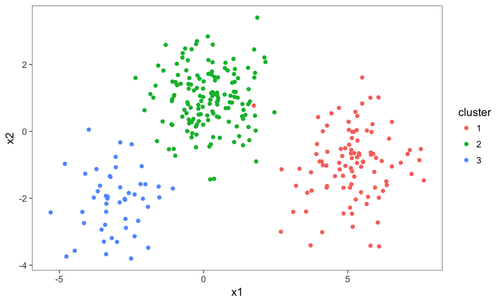

```r
set.seed(2014)
centers <- data_frame(cluster = factor(1:3),
                      size = c(100, 150, 50),
                      x1 = c(5, 0, -3),
                      x2 = c(-1, 1, -2))
points <- centers %>%
  group_by(cluster) %>%
  do(data_frame(x1 = rnorm(.$size[1], .$x1[1]),
                x2 = rnorm(.$size[1], .$x2[1])))
ggplot(points, aes(x1, x2, color = cluster)) + geom_point()
```

Let's try doing \(k\)-means clustering on this data.

```r
pts_matrix <- cbind(x1 = points$x1, x2 = points$x2)
kclust <- kmeans(pts_matrix, 3)
kclust
```

```
## K-means clustering with 3 clusters of sizes 99, 151, 50
##
## Cluster means:
##           x1         x2
## 1  5.1791917 -0.9865170
## 2  0.1583797  0.9797098
## 3 -3.0653196 -2.0887225
##
## Clustering vector:
##   [1] 1 1 1 1 1 1 1 1 1 1 1 1 1 1 1 1 1 1 1 1 1 1 1 1 1 1 1 1 1 1 1 1 1 1 1
##  [36] 1 1 1 1 1 1 1 1 1 1 1 1 1 1 1 1 1 1 1 1 1 1 1 1 1 1 1 1 1 1 1 1 1 1 1
##  [71] 1 1 1 1 1 1 1 1 1 1 1 1 1 1 1 1 1 1 1 2 1 1 1 1 1 1 1 1 1 1 2 2 2 2 2
## [106] 2 2 2 2 2 2 2 2 2 2 2 2 2 2 2 2 2 2 2 2 2 2 2 2 2 2 2 2 2 2 2 2 2 2 2
## [141] 2 2 2 2 2 2 2 2 2 2 2 2 2 2 2 2 2 2 2 2 2 2 2 2 2 2 2 2 2 2 2 2 2 2 2
## [176] 2 2 2 2 2 2 2 2 2 2 2 2 2 2 2 2 2 2 2 2 2 2 2 2 2 2 2 2 2 2 2 2 2 2 2
## [211] 2 2 2 2 2 2 2 2 2 2 2 2 2 2 2 2 2 2 2 2 2 2 2 2 2 2 2 2 2 2 2 2 2 2 2
## [246] 2 2 2 2 2 3 3 3 3 3 3 3 3 3 3 3 3 3 3 3 3 3 3 3 3 3 3 3 3 3 3 3 3 3 3
## [281] 3 3 3 3 3 3 3 3 3 3 3 3 3 3 3 3 3 3 3 3
##
## Within cluster sum of squares by cluster:
## [1] 204.96483 257.20360  78.64255
##  (between_SS / total_SS =  85.1 %)
##
## Available components:
##
## [1] "cluster"      "centers"      "totss"        "withinss"
## [5] "tot.withinss" "betweenss"    "size"         "iter"
## [9] "ifault"
```

```r
kclust %>% augment(pts_matrix) %>% as_tibble()
```

```
## # A tibble: 300 × 3
##          x1         x2 .cluster
##       <dbl>      <dbl>   <fctr>
## 1  4.434320  0.5416470        1
## 2  5.321046 -0.9412882        1
## 3  5.125271 -1.5802282        1
## 4  6.353225 -1.6040549        1
## 5  3.712270 -3.4079344        1
## 6  5.322555 -0.7716317        1
## 7  5.266928  0.5857579        1
## 8  5.399710 -0.7006604        1
## 9  5.458846 -1.8196312        1
## 10 7.150210 -0.5586259        1
## # ... with 290 more rows
```

```r
tidy(kclust) %>% as_tibble()
```

```
## # A tibble: 3 × 5
##           x1         x2  size  withinss cluster
## *      <dbl>      <dbl> <int>     <dbl>  <fctr>
## 1  5.1791917 -0.9865170    99 204.96483       1
## 2  0.1583797  0.9797098   151 257.20360       2
## 3 -3.0653196 -2.0887225    50  78.64255       3
```

Let's say we wanted to look at different choices for \(k\). First, do `kmeans` once for every value of \(k\).

```r
kclusts <- data_frame(k = 1:9) %>% group_by(k) %>% do(kclust = kmeans(pts_matrix, .$k))
```

Then tidy the results in all three ways.

```r
clusters <- kclusts %>% group_by(k) %>% do(tidy(.$kclust[[1]]))
assignments <- kclusts %>% group_by(k) %>% do(augment(.$kclust[[1]], pts_matrix))
clusterings <- kclusts %>% group_by(k) %>% do(glance(.$kclust[[1]]))
clusterings
```

```
## Source: local data frame [9 x 5]
## Groups: k [9]
##
##       k   totss tot.withinss     betweenss  iter
##   <int>   <dbl>        <dbl>         <dbl> <int>
## 1     1 3629.67    3629.6700 -3.637979e-12     1
## 2     2 3629.67    1284.7688  2.344901e+03     1
## 3     3 3629.67     540.8110  3.088859e+03     2
## 4     4 3629.67     444.4108  3.185259e+03     3
## 5     5 3629.67     427.1034  3.202567e+03     3
## 6     6 3629.67     329.8072  3.299863e+03     3
## 7     7 3629.67     353.0448  3.276625e+03     2
## 8     8 3629.67     289.7147  3.339955e+03     3
## 9     9 3629.67     234.2451  3.395425e+03     4
```

Now we can plot the data colored by cluster.

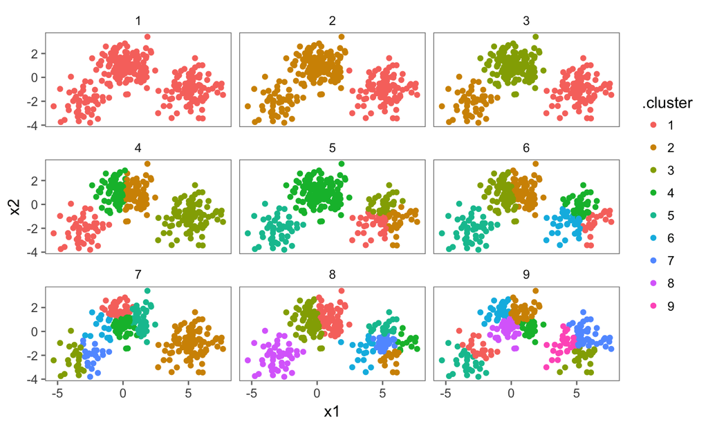

```r
p1 <- ggplot(assignments, aes(x1, x2)) + geom_point(aes(color = .cluster)) + facet_wrap(~k)
p1
```

We can use the `tidy()` output to add the centers.

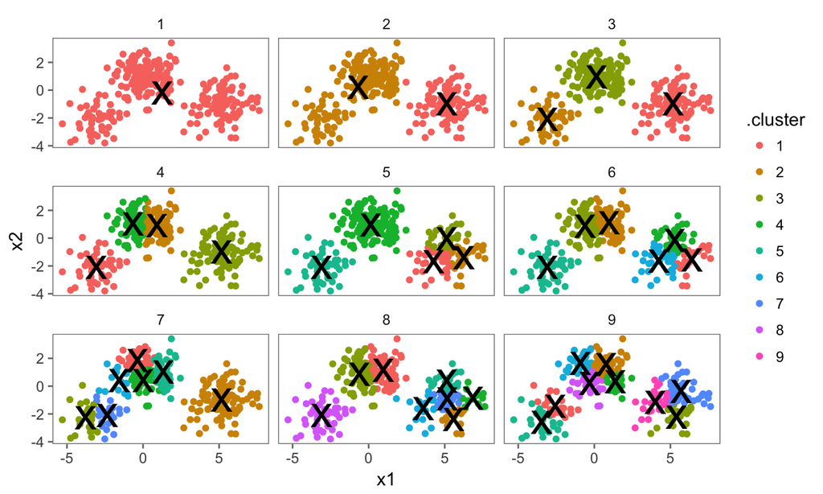

```r
p2 <- p1 + geom_point(data = clusters, size = 10, shape = 'x')
p2
```

Finally, we can use the `glance()` output to see the total within sum of squares for each \(k\).

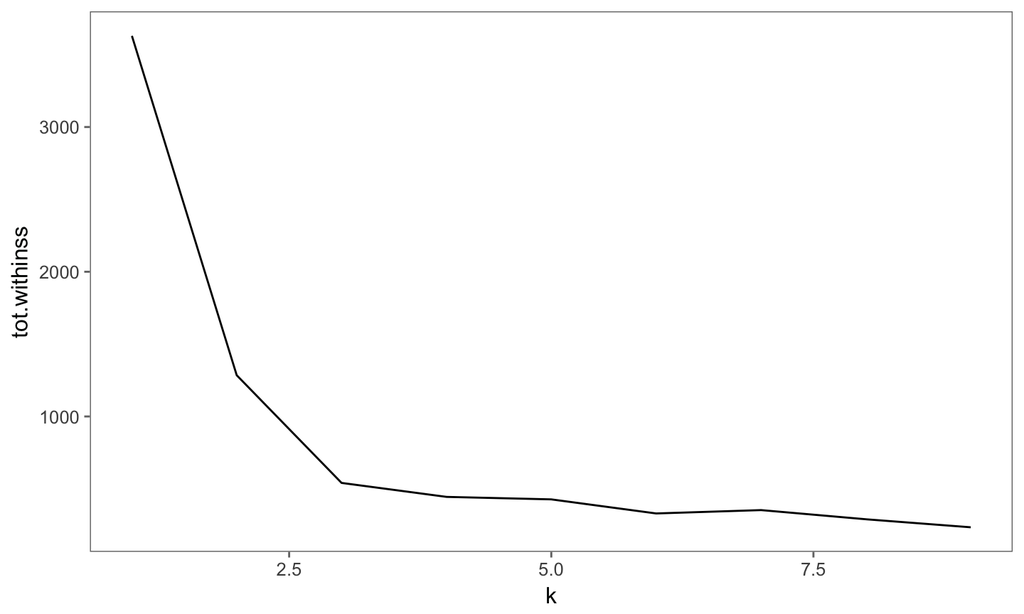

```r
ggplot(clusterings, aes(k, tot.withinss)) + geom_line()
```